# Linear Methods for Regression

### ESL Chapter-3

### Introduction:

A linear regression model assumes that the regression function E[Y|X] is linear in the inputs. Linear models were largely developed in the pre-computer era of statistics, but even in today's computer era they are still good reasons to study an use them. They are simple and often provide an adequate and interpretable description of how the inputs affect the output.

**For prediction purposes they can sometimes outperform fancier non linear models, especially in situations with small number of training cases, low signal to noise ration or sparse data. Finally, linear metods can be applied to transformations of the inputs and this considerably expands their scope.**

We will start with the simplest linear method that is multiple linear regression.

### Multiple Linear Regression Single output Case

For the sake of reproducibility we will work with a very simple dataset. </p>

```python
import numpy as np
import pandas as pd
```

```python
#Dataset
Stock_Market = {'Year': [2017,2017,2017,2017,2017,2017,2017,2017,2017,2017,2017,2017,2016,2016,2016,2016,2016,2016,2016,2016,2016,2016,2016,2016],
                'Month': [12, 11,10,9,8,7,6,5,4,3,2,1,12,11,10,9,8,7,6,5,4,3,2,1],
                'Interest_Rate': [2.75,2.5,2.5,2.5,2.5,2.5,2.5,2.25,2.25,2.25,2,2,2,1.75,1.75,1.75,1.75,1.75,1.75,1.75,1.75,1.75,1.75,1.75],
                'Unemployment_Rate': [5.3,5.3,5.3,5.3,5.4,5.6,5.5,5.5,5.5,5.6,5.7,5.9,6,5.9,5.8,6.1,6.2,6.1,6.1,6.1,5.9,6.2,6.2,6.1],
                'Stock_Index_Price': [1464,1394,1357,1293,1256,1254,1234,1195,1159,1167,1130,1075,1047,965,943,958,971,949,884,866,876,822,704,719]
                }
```

```python
df = pd.DataFrame(Stock_Market,columns=['Year','Month','Interest_Rate','Unemployment_Rate','Stock_Index_Price'])
df.head()
```

|  | Year | Month | Interest_Rate | Unemployment_Rate | Stock_Index_Price |
| --- | --- | --- | --- | --- | --- |
| 0 | 2017 | 12 | 2.75 | 5.3 | 1464 |
| 1 | 2017 | 11 | 2.50 | 5.3 | 1394 |
| 2 | 2017 | 10 | 2.50 | 5.3 | 1357 |
| 3 | 2017 | 9 | 2.50 | 5.3 | 1293 |
| 4 | 2017 | 8 | 2.50 | 5.4 | 1256 |

So quickly lets just understand what this data is about, here we have year , month , interest rate , unemployment rate and stockprice index. We are interested in stock price index and we will try to model it through interest rate and unemployment rate. Now let's fit a linear model:

```python
X = df[['Interest_Rate','Unemployment_Rate']]
Y = df['Stock_Index_Price']
```

```python
#Import part-2
from sklearn import linear_model
import statsmodels.api as sm
```

```python
#This is Using Sklearn
model = linear_model.LinearRegression()
model.fit(X,Y)
model.intercept_
```

```
1798.4039776258546
```

```python
model.coef_
```

```
array([ 345.54008701, -250.14657137])
```

So from the Sklearn model we can see it seems that Interest rate has strong positive association with the Stock Price and Unemployment rate has a negative association with the stock price. But again a point of caution this is in no way a statistically valid statement. It is merely a "layman"-ish hunch

```python
#This is Using Statsmodel
X = sm.add_constant(X) # adding a constant (intercept term)

model = sm.OLS(Y, X).fit()
model.summary()
```

OLS Regression Results

| Dep. Variable: | Stock_Index_Price | R-squared: | 0.898 |
| --- | --- | --- | --- |
| Model: | OLS | Adj. R-squared: | 0.888 |
| Method: | Least Squares | F-statistic: | 92.07 |
| Date: | Sun, 10 May 2020 | Prob (F-statistic): | 4.04e-11 |
| Time: | 16:59:59 | Log-Likelihood: | -134.61 |
| No. Observations: | 24 | AIC: | 275.2 |
| Df Residuals: | 21 | BIC: | 278.8 |
| Df Model: | 2 |  |  |
| Covariance Type: | nonrobust |  |  |

|  | coef | std err | t | P>\|t\| | [0.025 | 0.975] |
| --- | --- | --- | --- | --- | --- | --- |
| const | 1798.4040 | 899.248 | 2.000 | 0.059 | -71.685 | 3668.493 |
| Interest_Rate | 345.5401 | 111.367 | 3.103 | 0.005 | 113.940 | 577.140 |
| Unemployment_Rate | -250.1466 | 117.950 | -2.121 | 0.046 | -495.437 | -4.856 |

| Omnibus: | 2.691 | Durbin-Watson: | 0.530 |
| --- | --- | --- | --- |
| Prob(Omnibus): | 0.260 | Jarque-Bera (JB): | 1.551 |
| Skew: | -0.612 | Prob(JB): | 0.461 |
| Kurtosis: | 3.226 | Cond. No. | 394. |

Warnings:  
[1] Standard Errors assume that the covariance matrix of the errors is correctly specified.

**Now this is something that is desirable to us , from this table we can conclude that both Interest rate and Unemployment rate have significant effect on stock price index. While one having positive effect, another have strong negative effect (at level 0.05)**

Once this is done next important thing to check if the linearity assumption is at all valid, we will proceed to do that now

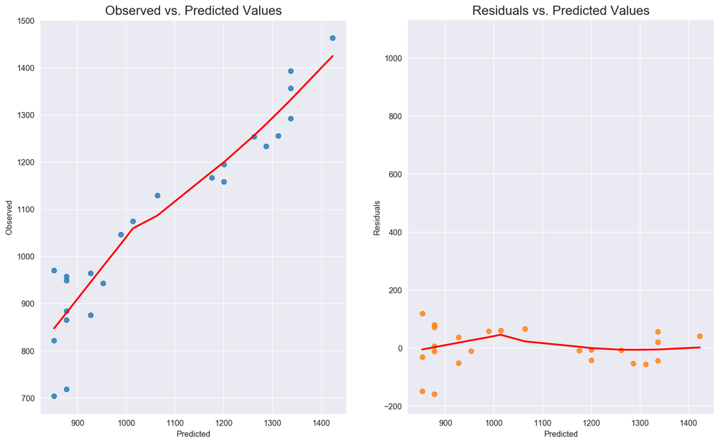

```python
%matplotlib inline
%config InlineBackend.figure_format ='retina'
import seaborn as sns
import matplotlib.pyplot as plt
import statsmodels.stats.api as sms
sns.set_style('darkgrid')
sns.mpl.rcParams['figure.figsize'] = (15.0, 9.0)

def linearity_test(model, y):
    '''
    Function for visually inspecting the assumption of linearity in a linear regression model.
    It plots observed vs. predicted values and residuals vs. predicted values.

    Args:
    * model - fitted OLS model from statsmodels
    * y - observed values
    '''
    fitted_vals = model.predict()
    resids = model.resid

    fig, ax = plt.subplots(1,2)

    sns.regplot(x=fitted_vals, y=y, lowess=True, ax=ax[0], line_kws={'color': 'red'})
    ax[0].set_title('Observed vs. Predicted Values', fontsize=16)
    ax[0].set(xlabel='Predicted', ylabel='Observed')

    sns.regplot(x=fitted_vals, y=resids, lowess=True, ax=ax[1], line_kws={'color': 'red'})
    ax[1].set_title('Residuals vs. Predicted Values', fontsize=16)
    ax[1].set(xlabel='Predicted', ylabel='Residuals')

linearity_test(model, Y)
```

So as the datas are more or less symetrically placed around the diagonal line we can claim that the linearity assumption was a valid assumption

#### Multiple Linear Regression Multi-Output Case

In this one instead of using real data I will use a data that is simulated from python itseld. Sklearn provides a neat method for that, so first we will do that

```python
from sklearn.datasets import make_regression
from sklearn.linear_model import LinearRegression
# create datasets
X, y = make_regression(n_samples=1000, n_features=10, n_informative=5, n_targets=2, random_state=1)
#So we have taken a sample of size 1000 , number of features = 10 , number of informative features =5 and number of outputs = 2
```

```python
#fitting the model
model = linear_model.LinearRegression()
model.fit(X,y)
```

```
LinearRegression(copy_X=True, fit_intercept=True, n_jobs=None,
         normalize=False)
```

```python
model.predict([np.random.random(10)]) #Prediction Method
```

```
array([[114.51863086,  84.81751386]])
```

### Subset Selection Methods:

There can be thousands of reasons to be disgusted with least square estimates but there are two main reason which causes those!

- Prediction Accuracy: Let's be honest here, I haven't seen a single case were OLS estimates ends up getting the best prediction accuracy (apart from some tailor made models maybe).The reason for this is least square estimates have low bias and large variance. Prediction accuracy can sometimes be improved by shrinking or setting some co-efficients to be 0
- Interpretation: With a large number of predictors, we often would like to determine a smaller subset that exhibit the strongest effects. In order to get the “big picture,” we are willing to sacrifice some of the small details

There are quite a few methods to accomplish this goal and we will cover most of them here.

#### Best Subset Selection:

Best subset regression finds for each k ∈ {0, 1, 2, . . . , p} the subset of size k that gives smallest residual sum of squares. An efficient algorithm —the leaps and bounds procedure (Furnival and Wilson, 1974)—makes this feasible for p as large as 30 or 40. Now note that the best subset curve is necessarily decreasing, so cannot be used to select the subset size k. The question of how to choose k involves the trade-off between bias and variance. *When all said and done this is not a method we will use in general , so if you want to use it best is to write your own code. I will upload a general code for this one(atleast for the case when p is less than 40), keep looking at my website it will be posted soon.*

#### Forward and Backward Stepwise Selection:

From one of the least used method to one of the heavily used method, Forward and backward stepwise selection is one of the most applied method. Rather than search through all possible subsets, we can seek a good path through them. Forward stepwise starts with the intercept and then sequentially adds into the model predictor that improves the fit. Backward stepwise starts with the full model and sequentially deletes the predictor that has the least impact on the fit. The candidate for dropping is the variable with the smallest z-score.

*Backward selection can only be used when N>p, while forward selection can always be used. Finally,note that often variables come in groups (dummy variables). Smart stepwise procedure (such as step in R) will add or drop whole groups at a time, taking proper account of their degrees of freedom.*

```python
#Dataset
from sklearn.datasets import load_boston
boston = load_boston()
import pandas as pd
bos = pd.DataFrame(boston.data, columns = boston.feature_names)
bos['Price'] = boston.target
X = bos.drop("Price", 1)       # feature matrix
y = bos['Price']               # target feature
bos.head()
```

|  | CRIM | ZN | INDUS | CHAS | NOX | RM | AGE | DIS | RAD | TAX | PTRATIO | B | LSTAT | Price |
| --- | --- | --- | --- | --- | --- | --- | --- | --- | --- | --- | --- | --- | --- | --- |
| 0 | 0.00632 | 18.0 | 2.31 | 0.0 | 0.538 | 6.575 | 65.2 | 4.0900 | 1.0 | 296.0 | 15.3 | 396.90 | 4.98 | 24.0 |
| 1 | 0.02731 | 0.0 | 7.07 | 0.0 | 0.469 | 6.421 | 78.9 | 4.9671 | 2.0 | 242.0 | 17.8 | 396.90 | 9.14 | 21.6 |
| 2 | 0.02729 | 0.0 | 7.07 | 0.0 | 0.469 | 7.185 | 61.1 | 4.9671 | 2.0 | 242.0 | 17.8 | 392.83 | 4.03 | 34.7 |
| 3 | 0.03237 | 0.0 | 2.18 | 0.0 | 0.458 | 6.998 | 45.8 | 6.0622 | 3.0 | 222.0 | 18.7 | 394.63 | 2.94 | 33.4 |
| 4 | 0.06905 | 0.0 | 2.18 | 0.0 | 0.458 | 7.147 | 54.2 | 6.0622 | 3.0 | 222.0 | 18.7 | 396.90 | 5.33 | 36.2 |

```python
#Forward Selection using manual function
import statsmodels.api as sm
def forward_selection(data, target, significance_level=0.05):
    initial_features = data.columns.tolist()
    best_features = []
    while (len(initial_features)>0):
        remaining_features = list(set(initial_features)-set(best_features))
        new_pval = pd.Series(index=remaining_features)
        for new_column in remaining_features:
            model = sm.OLS(target, sm.add_constant(data[best_features+[new_column]])).fit()
            new_pval[new_column] = model.pvalues[new_column]
        min_p_value = new_pval.min()
        if(min_p_value<significance_level):
            best_features.append(new_pval.idxmin())
        else:
            break
    return best_features
```

```python
forward_selection(X,y)
```

```
['LSTAT',
 'RM',
 'PTRATIO',
 'DIS',
 'NOX',
 'CHAS',
 'B',
 'ZN',
 'CRIM',
 'RAD',
 'TAX']
```

```python
#Forward Selection Using Python In-built Function
import mlxtend
from mlxtend.feature_selection import SequentialFeatureSelector as SFS
from sklearn.linear_model import LinearRegression
# Sequential Forward Selection(sfs)
sfs = SFS(LinearRegression(), k_features=11, forward=True,floating=False,scoring = 'r2', cv = 0) #here we want to select 11 features
```

```python
sfs.fit(X, y)
sfs.k_feature_names_     # to get the final set of features
```

```
('CRIM',
 'ZN',
 'CHAS',
 'NOX',
 'RM',
 'DIS',
 'RAD',
 'TAX',
 'PTRATIO',
 'B',
 'LSTAT')
```

```python
#Backward Selection Using manual function
def backward_elimination(data, target,significance_level = 0.05):
    features = data.columns.tolist()
    while(len(features)>0):
        features_with_constant = sm.add_constant(data[features])
        p_values = sm.OLS(target, features_with_constant).fit().pvalues[1:]
        max_p_value = p_values.max()
        if(max_p_value >= significance_level):
            excluded_feature = p_values.idxmax()
            features.remove(excluded_feature)
        else:
            break
    return features
```

```python
backward_elimination(X,y)
```

```
['CRIM',
 'ZN',
 'CHAS',
 'NOX',
 'RM',
 'DIS',
 'RAD',
 'TAX',
 'PTRATIO',
 'B',
 'LSTAT']
```

```python
#Using in-built function
sbs = SFS(LinearRegression(), k_features=11, forward=False, floating=False,cv=0)
sbs.fit(X, y)
sbs.k_feature_names_
```

```
('CRIM',
 'ZN',
 'CHAS',
 'NOX',
 'RM',
 'DIS',
 'RAD',
 'TAX',
 'PTRATIO',
 'B',
 'LSTAT')
```

Now one obvious question is won't it be better if we somehow get the value of number of features from the data rather than manually guessing it? Well yes and there is a way to do that, next I will discuss that

```python
#Here we created a model that will check for all k in (1,13)
sfs1 = SFS(LinearRegression(),
          k_features=(1,13),
          forward=True,
          floating=False,
          cv=0)
sfs1.fit(X, y)
```

```
SequentialFeatureSelector(clone_estimator=True, cv=0,
             estimator=LinearRegression(copy_X=True, fit_intercept=True, n_jobs=None,
         normalize=False),
             fixed_features=None, floating=False, forward=True,
             k_features=(1, 13), n_jobs=1, pre_dispatch='2*n_jobs',
             scoring=None, verbose=0)
```

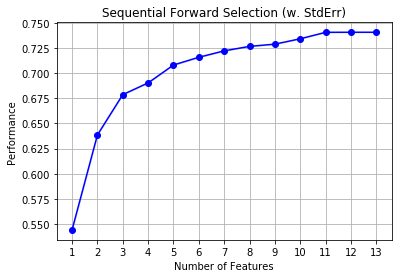

```python
from mlxtend.plotting import plot_sequential_feature_selection as plot_sfs
import matplotlib.pyplot as plt
fig1 = plot_sfs(sfs1.get_metric_dict(), kind='std_dev')
plt.title('Sequential Forward Selection (w. StdErr)')
plt.grid()
plt.show()
```

So as we can see from k =11 onward the performance becomes stable so selecting k=11 is a sef bet (although 10 is a very close option too)

```python
#Bi-Directional Method:
sffs = SFS(LinearRegression(),
          k_features=(3,11),
          forward=True,
          floating=True,
          cv=0)
sffs.fit(X, y)
sffs.k_feature_names_
```

```
('CRIM',
 'ZN',
 'CHAS',
 'NOX',
 'RM',
 'DIS',
 'RAD',
 'TAX',
 'PTRATIO',
 'B',
 'LSTAT')
```

#### Forward Stagewise Regression

Forward stagewise regression is even more constrained than forward stepwise regression, with an intercept equals mean(y) , and centered predictors with co-efficients initially all 0. At each step the algorithm identifies the variable most correlated with the current residual. It then computes the simple linear regression co-efficient for that variable. This continue till none of the variables have correlation with residuals. This method pays dividend in high dimensional problems. *This method also needs custom made implementation , I will provide one soon so keep looking at my home page*

### Shrinkage Methods:

By retaining a subset of the predictors and discarding the rest,subset selection produces a model that is interpretable and has possibly lower prediction error than the full model. However, because it is a discrete process - variables are either retained or discarded - it often exhibit high variance. Shrinkage methods are more continuous , and don't suffer as much from high variability.

#### Ridge Regression:

Ridge regression shrinks the regression coefficients by imposing a penalty on their size.The ridge coefficients minimize a penalized residual sum of squares. It takes into account L2 norm. For more details on Ridge Regression check here: https://en.wikipedia.org/wiki/Tikhonov_regularization

```python
#Importing Libraries as Always
from sklearn.datasets import load_boston
from sklearn.linear_model import Ridge, RidgeCV
from sklearn.metrics import mean_squared_error
from sklearn.model_selection import train_test_split
import matplotlib.pyplot as plt
import numpy as np
```

```python
#Again our favorite nice and simple boston data
boston = load_boston()
x, y = boston.data, boston.target
xtrain, xtest, ytrain, ytest = train_test_split(x, y, test_size=0.15)
```

```python
alphas = [0.000001, 0.00001, 0.0001, 0.001, 0.01, 0.1,0.5, 1]
#This is our regularization parameter
```

```python
for a in alphas:
    model = Ridge(alpha=a, normalize=True).fit(x,y)
    score = model.score(x, y)
    pred_y = model.predict(x)
    mse = mean_squared_error(y, pred_y)
    print("Alpha:{0:.6f}, R2:{1:.3f}, MSE:{2:.2f}, RMSE:{3:.2f}".format(a, score, mse, np.sqrt(mse)))
```

```
Alpha:0.000001, R2:0.741, MSE:21.89, RMSE:4.68
Alpha:0.000010, R2:0.741, MSE:21.89, RMSE:4.68
Alpha:0.000100, R2:0.741, MSE:21.89, RMSE:4.68
Alpha:0.001000, R2:0.741, MSE:21.90, RMSE:4.68
Alpha:0.010000, R2:0.740, MSE:21.92, RMSE:4.68
Alpha:0.100000, R2:0.732, MSE:22.66, RMSE:4.76
Alpha:0.500000, R2:0.686, MSE:26.48, RMSE:5.15
Alpha:1.000000, R2:0.635, MSE:30.81, RMSE:5.55
```

```python
#So we can see that Alpha = 0.01 is a reasonable choice
ridge_mod=Ridge(alpha=0.01, normalize=True).fit(xtrain,ytrain)
ypred = ridge_mod.predict(xtest)
score = model.score(xtest,ytest)
mse = mean_squared_error(ytest,ypred)
print("R2:{0:.3f}, MSE:{1:.2f}, RMSE:{2:.2f}".format(score, mse,np.sqrt(mse)))
```

```
R2:0.549, MSE:32.54, RMSE:5.70
```

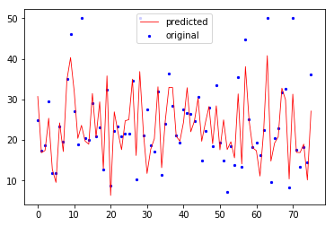

```python
#Let's Visualize
x_ax = range(len(xtest))
plt.scatter(x_ax, ytest, s=5, color="blue", label="original")
plt.plot(x_ax, ypred, lw=0.8, color="red", label="predicted")
plt.legend()
plt.show()
```

```python
#Now instead of picking the regularization parameter manually there is also another way out
ridge_cv=RidgeCV(alphas=alphas, store_cv_values=True)
ridge_mod = ridge_cv.fit(xtrain,ytrain)
print(ridge_mod.alpha_)
```

```
0.01
```

#### Lasso:

The lasso is also a shrinkage method but it uses L1 norm which causes some of the co-efficients to be shrunked to 0

```python
#Imports
import numpy as np
import pandas as pd
import matplotlib.pyplot as plt
%matplotlib inline
plt.style.use('ggplot')
import warnings; warnings.simplefilter('ignore') #This is my favorite import XD
```

```python
#We will use a different dataset here and will only use 200 observations
df = pd.read_csv("https://raw.githubusercontent.com/kirenz/datasets/master/Auto.csv")
df = df.iloc[0:200]
df = df.drop(['name'], axis=1)
df.info()
```

```
<class 'pandas.core.frame.DataFrame'>
RangeIndex: 200 entries, 0 to 199
Data columns (total 8 columns):
 #   Column        Non-Null Count  Dtype
---  ------        --------------  -----
 0   mpg           200 non-null    float64
 1   cylinders     200 non-null    int64
 2   displacement  200 non-null    float64
 3   horsepower    200 non-null    object
 4   weight        200 non-null    int64
 5   acceleration  200 non-null    float64
 6   year          200 non-null    int64
 7   origin        200 non-null    int64
dtypes: float64(3), int64(4), object(1)
memory usage: 12.6+ KB
```

```python
df['origin'] = pd.Categorical(df['origin'])
df['horsepower'] = pd.to_numeric(df['horsepower'], errors='coerce')
print(df.isnull().sum())
```

```
mpg             0
cylinders       0
displacement    0
horsepower      2
weight          0
acceleration    0
year            0
origin          0
dtype: int64
```

```python
#so we can see there are 2 null values we have to edit them
df = df.dropna()
```

```python
dfs = df.astype('int') #changed all values to int
```

```python
#Standardization
from sklearn.preprocessing import StandardScaler

scaler = StandardScaler()
dfs[['cylinders', 'displacement', 'horsepower',
     'weight', 'acceleration', 'year', 'origin']] = scaler.fit_transform(dfs[['cylinders',
                                                                              'displacement',
                                                                              'horsepower',
                                                                              'weight',
                                                                              'acceleration',
                                                                              'year', 'origin']])
```

```python
dfs.head()
```

|  | mpg | cylinders | displacement | horsepower | weight | acceleration | year | origin |
| --- | --- | --- | --- | --- | --- | --- | --- | --- |
| 0 | 18 | 1.179744 | 0.726091 | 0.325216 | 0.346138 | -0.955578 | -1.516818 | -0.629372 |
| 1 | 15 | 1.179744 | 1.100254 | 1.129264 | 0.548389 | -1.305309 | -1.516818 | -0.629372 |
| 2 | 18 | 1.179744 | 0.821807 | 0.784672 | 0.273370 | -1.305309 | -1.516818 | -0.629372 |
| 3 | 16 | 1.179744 | 0.699986 | 0.784672 | 0.270160 | -0.955578 | -1.516818 | -0.629372 |
| 4 | 17 | 1.179744 | 0.682583 | 0.554944 | 0.287282 | -1.655041 | -1.516818 | -0.629372 |

```python
from sklearn.model_selection import train_test_split
X = dfs.drop(['mpg'], axis=1)
y = dfs['mpg']

X_train, X_test, y_train, y_test = train_test_split(X, y, test_size=0.25, random_state=10)


from sklearn.linear_model import Lasso

reg = Lasso(alpha=0.5)
reg.fit(X_train, y_train)
print('Lasso Regression: R^2 score on training set', reg.score(X_train, y_train)*100)
print('Lasso Regression: R^2 score on test set', reg.score(X_test, y_test)*100)
```

```
Lasso Regression: R^2 score on training set 82.49741060950073
Lasso Regression: R^2 score on test set 85.49734440925533
```

```python
#Now again it is not a good practice to fix alpha so we will perform 5-fold cross validation
#Setting up
l_min = 0.05
l_max = 1.0
l_num = 1000
lambdas = np.linspace(l_min,l_max, l_num)

train_r_squared = np.zeros(l_num)
test_r_squared = np.zeros(l_num)

pred_num = X.shape[1]
coeff_a = np.zeros((l_num, pred_num))
```

[figure not shown]

```python
from sklearn.model_selection import cross_val_score

for ind, i in enumerate(lambdas):
    reg = Lasso(alpha = i)
    reg.fit(X_train, y_train)
    results = cross_val_score(reg, X, y, cv=5, scoring="r2")

    train_r_squared[ind] = reg.score(X_train, y_train)
    test_r_squared[ind] = reg.score(X_test, y_test)
plt.figure(figsize=(18, 8))
plt.plot(train_r_squared, 'bo-', label=r'$R^2$ Training set', color="darkblue", alpha=0.6, linewidth=3)
plt.plot(test_r_squared, 'bo-', label=r'$R^2$ Test set', color="darkred", alpha=0.6, linewidth=3)
plt.xlabel('Lamda value'); plt.ylabel(r'$R^2$')
plt.xlim(0, 19)
plt.title(r'Evaluate 5-fold cv with different lamdas')
plt.legend(loc='best')
plt.grid()
```

```python
#Best Lambda
df_lam = pd.DataFrame(test_r_squared*100, columns=['R_squared'])
df_lam['lambda'] = (lambdas)
# returns the index of the row where column has maximum value.
df_lam.loc[df_lam['R_squared'].idxmax()]
```

```
R_squared    87.897525
lambda        0.050000
Name: 0, dtype: float64
```

So as we can see in this case we have got a very boring dataset , that is a dataset in which Lasso doesn't provide any upgrade, but still for the sake of completeness we will stick with alpha = 0.05

```python
# Best Model
reg_best = Lasso(alpha = 0.05)
reg_best.fit(X_train, y_train)
```

```
Lasso(alpha=0.05, copy_X=True, fit_intercept=True, max_iter=1000,
   normalize=False, positive=False, precompute=False, random_state=None,
   selection='cyclic', tol=0.0001, warm_start=False)
```

```python
from sklearn.metrics import mean_squared_error

mean_squared_error(y_test, reg_best.predict(X_test))
```

```
3.5330027825242594
```

```python
reg_best.coef_
```

```
array([-0.38007418, -1.07390555, -0.04740096, -3.3445837 , -0.02594997,
        0.42984925,  0.78784427])
```